# Heart Disease Data Analysis

- Show All Code
- Hide All Code

Heart disease data analysis, and model building

Author

Ethan Glenn

Published

April 9, 2025

## Background

Heart disease remains a leading cause of morbidity and mortality worldwide. Early identification of individuals at high risk is crucial for timely intervention and prevention. This project is aimed to leverage machine learning – specifically its ability to model complex, non-linear interactions between clinical features – to develop a predictive model for assessing the likelihood of heart disease based on patient clinical data. This data utilized was sourced from the widely recognized UC Irvine Machine Learning Repository dataset. The objective of this is to build a reliable model that could potentially aid healthcare professionals in risk stratification.

## Exploring the Data

First, let’s take a look at the data features, the initial rows, and general information about the dataset structure to understand what we are working with.

```python
df = pd.read_csv('heart-disease.csv')
```

```python
df.head()
```

|  | Unnamed: 0 | age | sex | cp | trestbps | chol | fbs | restecg | thalach | exang | oldpeak | slope | ca | thal | num |
| --- | --- | --- | --- | --- | --- | --- | --- | --- | --- | --- | --- | --- | --- | --- | --- |
| 0 | 0 | 63 | 1 | 1 | 145 | 233 | 1 | 2 | 150 | 0 | 2.3 | 3 | 0.0 | 6.0 | 0 |
| 1 | 1 | 67 | 1 | 4 | 160 | 286 | 0 | 2 | 108 | 1 | 1.5 | 2 | 3.0 | 3.0 | 2 |
| 2 | 2 | 67 | 1 | 4 | 120 | 229 | 0 | 2 | 129 | 1 | 2.6 | 2 | 2.0 | 7.0 | 1 |
| 3 | 3 | 37 | 1 | 3 | 130 | 250 | 0 | 0 | 187 | 0 | 3.5 | 3 | 0.0 | 3.0 | 0 |
| 4 | 4 | 41 | 0 | 2 | 130 | 204 | 0 | 2 | 172 | 0 | 1.4 | 1 | 0.0 | 3.0 | 0 |

```python
df.info()
```

```
<class 'pandas.core.frame.DataFrame'>
RangeIndex: 303 entries, 0 to 302
Data columns (total 15 columns):
 #   Column      Non-Null Count  Dtype
---  ------      --------------  -----
 0   Unnamed: 0  303 non-null    int64
 1   age         303 non-null    int64
 2   sex         303 non-null    int64
 3   cp          303 non-null    int64
 4   trestbps    303 non-null    int64
 5   chol        303 non-null    int64
 6   fbs         303 non-null    int64
 7   restecg     303 non-null    int64
 8   thalach     303 non-null    int64
 9   exang       303 non-null    int64
 10  oldpeak     303 non-null    float64
 11  slope       303 non-null    int64
 12  ca          299 non-null    float64
 13  thal        301 non-null    float64
 14  num         303 non-null    int64
dtypes: float64(3), int64(12)
memory usage: 35.6 KB
```

*Interpretation*: The .info() output confirms 303 initial entries and 15 columns. Most features are numerical (int64 or float64). Crucially, it reveals missing values in the ca (4 missing) and thal (2 missing) columns, which will need addressing during data cleaning. The memory usage is minimal.

### Target Variable Distribution

Now I want to take a look at the distribution of our original target, the num column. This column indicates the presence and severity of heart disease on a scale of 0-4, where 0 indicates no presence, and 1-4 indicate increasing severity.

```python
df["num"].value_counts()
```

```
num
0    164
1     55
2     36
3     35
4     13
Name: count, dtype: int64
```

*Interpretation*: The majority of patients in the dataset have a num value of 0 (no disease). The counts decrease as the severity level increases. Given this distribution and the project’s goal to predict presence vs. absence, we will later transform this into a binary target variable (0 vs. 1-4 combined).

With this initial understanding, we can proceed to clean the data.

## Data Cleaning

Before we get to training a model, it’s essential to ensure data quality. We will address missing values, check for duplicates, and handle potential data outliers correctly.

First, we will check the number of unique values per feature to understand their nature (categorical vs. continuous) and re-examine the data types.

```python
df.nunique()
```

```
Unnamed: 0    303
age            41
sex             2
cp              4
trestbps       50
chol          152
fbs             2
restecg         3
thalach        91
exang           2
oldpeak        40
slope           3
ca              4
thal            3
num             5
dtype: int64
```

```python
df.dtypes
```

```
Unnamed: 0      int64
age             int64
sex             int64
cp              int64
trestbps        int64
chol            int64
fbs             int64
restecg         int64
thalach         int64
exang           int64
oldpeak       float64
slope           int64
ca            float64
thal          float64
num             int64
dtype: object
```

*Interpretation*: This confirms features like sex, cp, fbs, restecg, exang, slope, ca, and thal have a limited number of unique values, suggesting they are categorical or ordinal in nature, even if stored numerically. age, trestbps, chol, thalach, and oldpeak appear more continuous.

Let’s examine some key categorical features:

```python
df['sex'].unique()
```

```
array([1, 0])
```

*Interpretation*: The sex column contains only two unique values (likely 1 for male, 0 for female), as expected.

```python
df['cp'].unique()
```

```
array([1, 4, 3, 2])
```

Interpretation: The chest pain column (cp) has four distinct values (1-4), representing different types of chest pain, with no apparent missing values within the unique values shown here.

### Handling Missing Values

We previously identified missing values in thal and ca. Let’s investigate thal first.

```python
df['thal'].unique()
```

```
array([ 6.,  3.,  7., nan])
```

*Interpretation*: We confirm missing values (nan) exist in the thal column. Thalassemia (thal) testing relates to blood flow during stress tests and is likely an important indicator.

Let’s check the null counts again to confirm which columns have missing data.

```python
df.isnull().sum()
```

```
Unnamed: 0    0
age           0
sex           0
cp            0
trestbps      0
chol          0
fbs           0
restecg       0
thalach       0
exang         0
oldpeak       0
slope         0
ca            4
thal          2
num           0
dtype: int64
```

To address the missing `thal` values (2 instances), and the missing `ca` values (4 instances), we will impute them using the mean of the existing values. This simple approach allows us to retain the rows, though it might slightly reduce the feature’s variance. More sophisticated methods could be explored, but mean imputation suffices for this analysis.

```python
df_imputed = df.fillna(df.mean())
```

After imputing the `thal` values, we check again.

```python
df_imputed.isnull().sum()
```

```
Unnamed: 0    0
age           0
sex           0
cp            0
trestbps      0
chol          0
fbs           0
restecg       0
thalach       0
exang         0
oldpeak       0
slope         0
ca            0
thal          0
num           0
dtype: int64
```

*Interpretation*: The missing values in `thal` have been successfully imputed.

### Checking for Duplicates

We will also check for and remove any duplicate rows in the dataset.

```python
duplicated = df_imputed.duplicated().sum()
print(f'There are {duplicated} duplicated rows')
```

```
There are 0 duplicated rows
```

*Interpretation*: No duplicate rows were found.

### Creating the Target

Because we are trying to predict whether someone is prone to having heart disease (presence vs. absence), rather than the specific severity, we will create a new binary target column. If the original num value is 0 (no heart disease), the new `disease_binary` value will be 0. If num is 1, 2, 3, or 4, `disease_binary` will be 1, indicating the presence of heart disease.

```python
df_imputed['disease_binary'] = (df_imputed['num'] > 0).astype(int)
```

With the initial cleaning and target definition complete, we now address potential outliers.

### Handling Outliers

```python
continous_features = ['age','trestbps','chol','thalach','oldpeak']
def outliers(df_out, drop = False):
    for each_feature in df_out.columns:
        feature_data = df_out[each_feature]
        Q1 = np.percentile(feature_data, 25.)
        Q3 = np.percentile(feature_data, 75.)
        IQR = Q3-Q1
        outlier_step = IQR * 1.5
        outliers = feature_data[~((feature_data >= Q1 - outlier_step) & (feature_data <= Q3 + outlier_step))].index.tolist()
        if not drop:
            print('For the feature {}, No of Outliers is {}'.format(each_feature, len(outliers)))
        if drop:
            df.drop(outliers, inplace = True, errors = 'ignore')
            print('Outliers from {} feature removed'.format(each_feature))

outliers(df_imputed[continous_features])

outliers(df_imputed[continous_features], drop=True)

df_cleaned = df_imputed.copy()
```

```
For the feature age, No of Outliers is 0
For the feature trestbps, No of Outliers is 9
For the feature chol, No of Outliers is 5
For the feature thalach, No of Outliers is 1
For the feature oldpeak, No of Outliers is 5
Outliers from age feature removed
Outliers from trestbps feature removed
Outliers from chol feature removed
Outliers from thalach feature removed
Outliers from oldpeak feature removed
```

## Data Exploration

In this section, a series of charts will be generated and commented on in regards to their validity and what they tell us about the data.

### Distribution or Target Variable

This chart shows the distribution of our binary target variable, disease_binary.

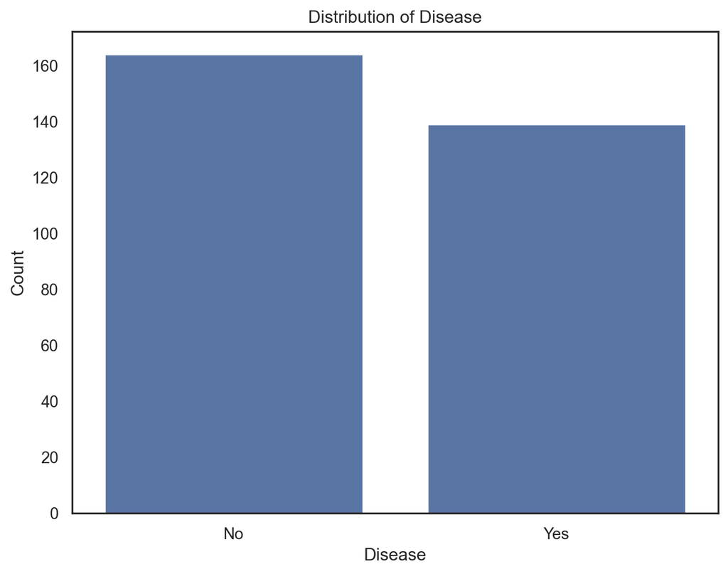

```
disease
No     54.125413
Yes    45.874587
Name: proportion, dtype: float64
```

```python
df_cleaned['disease'] = df_cleaned['num'].apply(lambda x: 'Yes' if x != 0 else 'No')
percent_diseased = df_cleaned['disease'].value_counts(normalize=True) * 100

plt.figure(figsize=(8, 6))
sns.countplot(x='disease', data=df_cleaned)
plt.title('Distribution of Disease')
plt.xlabel('Disease')
plt.ylabel('Count')
plt.show()

percent_diseased
```

*Interpretation*: The dataset, after cleaning, shows a reasonably balanced distribution between patients without heart disease (approx. 54%) and those with heart disease (approx. 46%). This balance is generally good for training a classification model without needing complex techniques to handle severe class imbalance.

### Sex Distribution by Disease

Let’s examine how heart disease prevalence differs between sexes in this dataset.

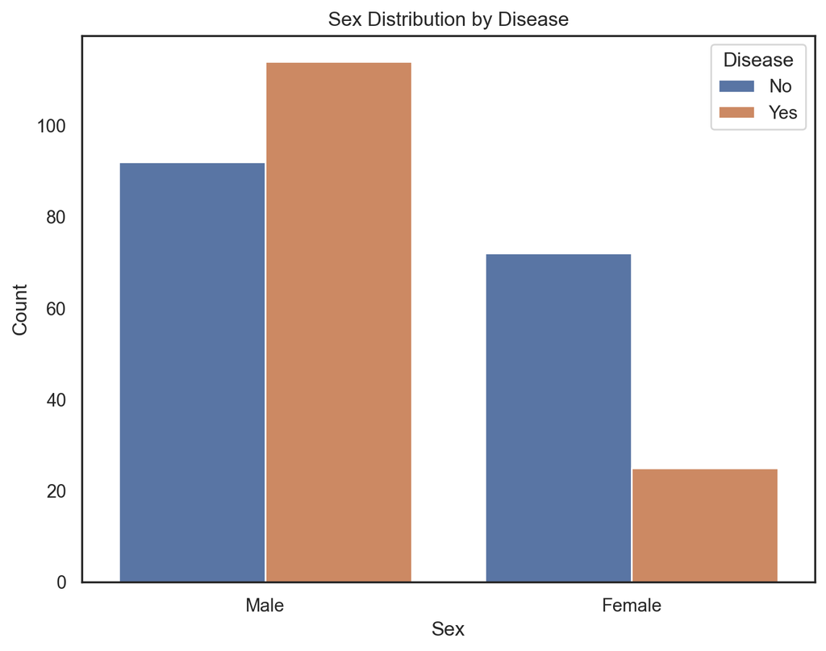

```python
sex_df = df_cleaned.copy()
sex_df['sex'] = sex_df['sex'].apply(lambda x: 'Female' if x == 0 else 'Male')

plt.figure(figsize=(8, 6))
sns.countplot(x='sex', hue='disease', data=sex_df)
plt.title('Sex Distribution by Disease')
plt.xlabel('Sex')
plt.ylabel('Count')
plt.legend(title='Disease')
plt.show()
```

### Chest Pain Type Distribution by Disease

This chart explores the relationship between different types of chest pain (cp) and the presence of heart disease.

- Chest Pain Type 1 (Typical Angina)
- Chest Pain Type 2 (Atypical Angina)
- Chest Pain Type 3 (Non-anginal Pain)
- Chest Pain Type 4 (Asymptomatic)

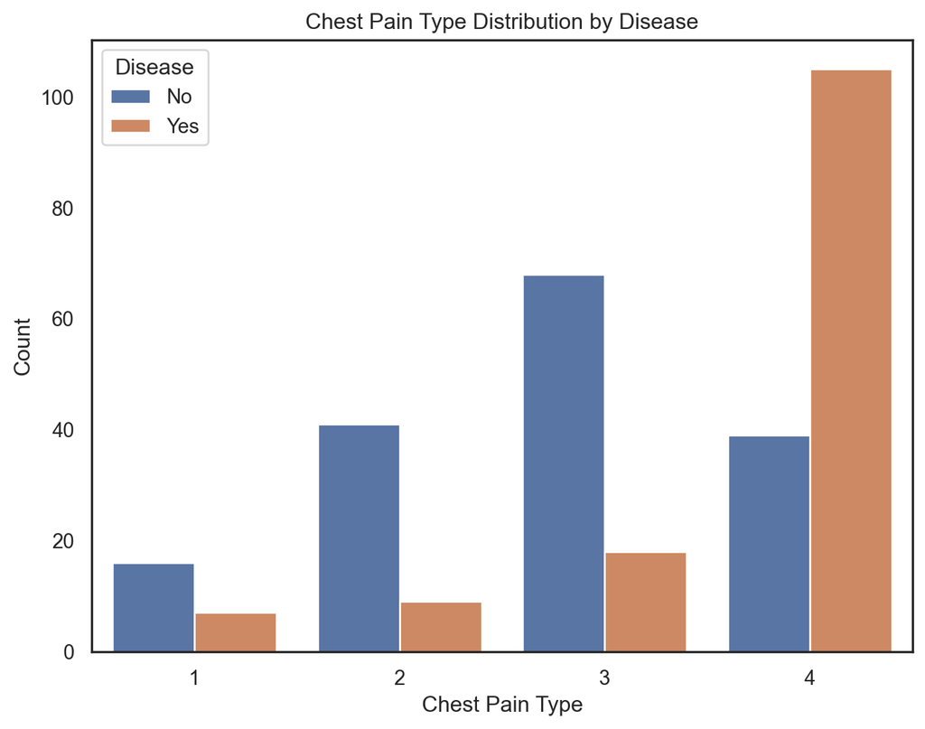

```python
plt.figure(figsize=(8, 6))
sns.countplot(x='cp', hue='disease', data=df_cleaned)
plt.title('Chest Pain Type Distribution by Disease')
plt.xlabel('Chest Pain Type')
plt.ylabel('Count')
plt.legend(title='Disease')
plt.show()
```

*Interpretation*: The chart highlights interesting patterns. Paradoxically, within this dataset, the absence of typical/atypical/non-anginal pain (Type 4 - Asymptomatic) is the strongest indicator for the presence of heart disease (highest orange bar). Conversely, reporting non-anginal pain (Type 3) is most common among those without heart disease (highest blue bar). This underscores the complex relationship between symptoms and diagnosis.

### Distributions of Key Continuous Features

As would be expected, we can see roughly normal or skewed distributions for the rest of our key continuous data features, as demonstrated below.

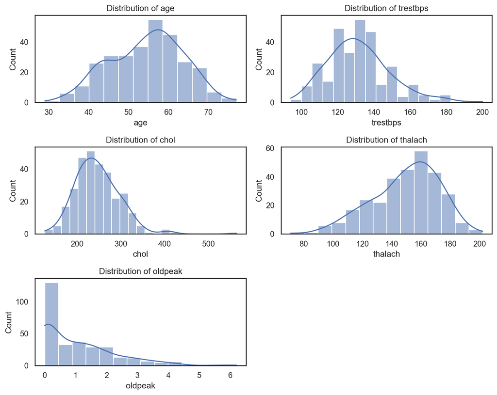

```python
fig, axes = plt.subplots(nrows=3, ncols=2, figsize=(10, 8))
axes = axes.flatten()

for i, feature in enumerate(continous_features):
    sns.histplot(df_cleaned[feature], kde=True, ax=axes[i])
    axes[i].set_title(f'Distribution of {feature}')

for i in range(len(continous_features), len(axes)):
  axes[i].axis('off')

plt.tight_layout()
plt.show()
```

*Interpretation*: These histograms show the distributions of `age`, `trestbps`, `chol`, and `oldpeak`. age appears roughly normally distributed. `trestbps` and `chol` show slight right skew. `oldpeak` is heavily right-skewed, indicating most patients have low values for ST depression.

### Feature Correlation

The following heatmap visualizes the pairwise correlation between all features, including our binary target `disease_binary`.

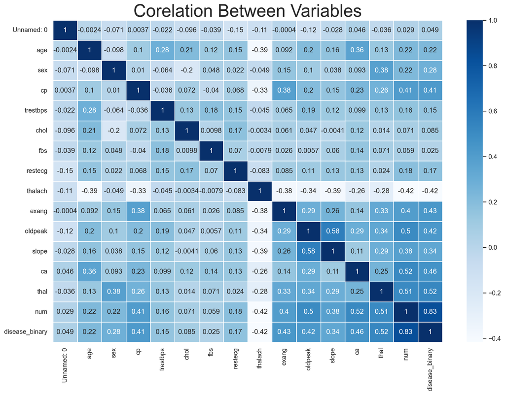

```python
sns.set(style="white")
plt.rcParams['figure.figsize'] = (15, 10)
numerical_df = df_cleaned.select_dtypes(include=np.number)
sns.heatmap(numerical_df.corr(), annot = True, linewidths=.5, cmap="Blues")
plt.title('Corelation Between Variables', fontsize = 30)
plt.show()
```

The exploratory analysis revealed key patterns and confirmed the suitability of the data. We now proceed to the model building phase.

## Model Generation

### Preparing Features and Target

We first separate the dataset into features (X - all columns except the target `disease_binary` and the original `num`) and the target variable (y - `disease_binary`). This step ensures the model focuses only on relevant predictors for the binary classification task.

```python
feature_cols = [col for col in df_cleaned.columns if col not in ['num', 'disease_binary', 'disease', 'disease_label']]
X = df_cleaned[feature_cols]
y = df_cleaned['disease_binary']

print(f"\n--- Preparing for Modeling ---")
print(f"Features shape: {X.shape}")
print(f"Target shape: {y.shape}")
print(f"Target distribution:\n{y.value_counts()}")
```

```
--- Preparing for Modeling ---
Features shape: (303, 14)
Target shape: (303,)
Target distribution:
disease_binary
0    164
1    139
Name: count, dtype: int64
```

### Splitting Data

The data is split into training (80%) and testing (20%) sets. We use stratification (stratify=y) to ensure that the proportion of patients with and without heart disease is approximately the same in both the training and testing sets. This is crucial for balanced evaluation, especially with moderately balanced datasets.

```python
X_train, X_test, y_train, y_test = train_test_split(X, y, test_size=0.2, random_state=42, stratify=y)
print(f"Train set shape: {X_train.shape}, Test set shape: {X_test.shape}")
```

```
Train set shape: (242, 14), Test set shape: (61, 14)
```

### Scaling Numeric Columns

Gradient Boosting models can benefit from feature scaling. We identify numeric columns that represent continuous values or wide ranges and standardize them to have a mean of 0 and a standard deviation of 1. Categorical features (even if numeric, like sex, cp) are excluded from scaling as they represent discrete categories.

```python
numeric_cols_to_scale = X_train.select_dtypes(include=np.number).columns.tolist()
known_categorical_numeric = ['sex', 'cp', 'fbs', 'restecg', 'exang', 'slope', 'ca', 'thal']
numeric_cols_final = [col for col in numeric_cols_to_scale if col not in known_categorical_numeric]
numeric_cols_final = [col for col in numeric_cols_final if col in X_train.columns]

print(f"\nNumeric columns identified for scaling: {numeric_cols_final}")
```

```
Numeric columns identified for scaling: ['Unnamed: 0', 'age', 'trestbps', 'chol', 'thalach', 'oldpeak']
```

Standardizing these features using StandardScaler ensures all scaled features contribute comparably to the model, preventing features with larger ranges from dominating the learning process.

```python
scaler = StandardScaler()

X_train_scaled = X_train.copy()
X_test_scaled = X_test.copy()

X_train_scaled[numeric_cols_final] = scaler.fit_transform(X_train[numeric_cols_final])
X_test_scaled[numeric_cols_final] = scaler.transform(X_test[numeric_cols_final])

print("Scaled Train Data Head:\n", X_train_scaled.head())
```

```
Scaled Train Data Head:
      Unnamed: 0       age  sex  cp  trestbps      chol  fbs  restecg  \
180    0.399085 -0.729485    1   4 -0.395692  0.458139    0        2
208    0.722786  0.050166    1   2 -0.054513  0.230598    0        0
167    0.248795 -0.061212    0   2  0.059213  0.723605    1        2
105   -0.467972 -0.061212    1   2 -1.305501  1.121803    0        0
297    1.751693  0.272924    0   4  0.514117 -0.167601    0        0

      thalach  exang   oldpeak  slope   ca  thal
180  0.708371      0 -0.445445      2  0.0   7.0
208  0.222495      0 -0.891627      1  0.0   3.0
167  0.399178      1 -0.891627      1  1.0   3.0
105  0.266666      0 -0.891627      1  0.0   7.0
297 -1.190962      1 -0.713154      2  0.0   7.0
```

### Training the Model 🦾

We will train a Gradient Boosting Classifier. This algorithm builds an additive model in a forward stage-wise fashion; it allows for the optimization of arbitrary differentiable loss functions. We initialize it with 100 estimators (trees), a learning rate of 0.1, and a maximum tree depth of 3.

```python
gb_model = GradientBoostingClassifier(n_estimators=100, learning_rate=0.1, max_depth=3, random_state=42)
gb_model.fit(X_train_scaled, y_train)
print("Model training complete.")
```

```
Model training complete.
```

Generating predictions for both the training and testing datasets. These predictions will be used to evaluate the model’s performance.

```python
y_pred_train = gb_model.predict(X_train_scaled)
y_pred_test = gb_model.predict(X_test_scaled)
```

Evaluating the model’s performance using metrics like accuracy, recall, and precision. The classification report provides a detailed breakdown of the model’s performance for each class (disease vs. no disease).

```python
train_accuracy = accuracy_score(y_train, y_pred_train)
test_accuracy = accuracy_score(y_test, y_pred_test)
recall = recall_score(y_test, y_pred_test)
precision = precision_score(y_test, y_pred_test)
print(f"Training Accuracy: {train_accuracy:.4f}")
print(f"Test Accuracy: {test_accuracy:.4f}")
print(f"Recall: {recall:.4f}")
print(f"Precision: {precision:.4f}")

print("\nClassification Report (Test Set):")
print(classification_report(y_test, y_pred_test, target_names=['No Disease (0)', 'Disease (1)']))
```

```
Training Accuracy: 0.9959
Test Accuracy: 0.8689
Recall: 0.9286
Precision: 0.8125

Classification Report (Test Set):
                precision    recall  f1-score   support

No Disease (0)       0.93      0.82      0.87        33
   Disease (1)       0.81      0.93      0.87        28

      accuracy                           0.87        61
     macro avg       0.87      0.87      0.87        61
  weighted avg       0.88      0.87      0.87        61
```

Plotting the confusion matrix as a heatmap for easier interpretation of the model’s performance. This visualization highlights the balance between true positives, true negatives, false positives, and false negatives.

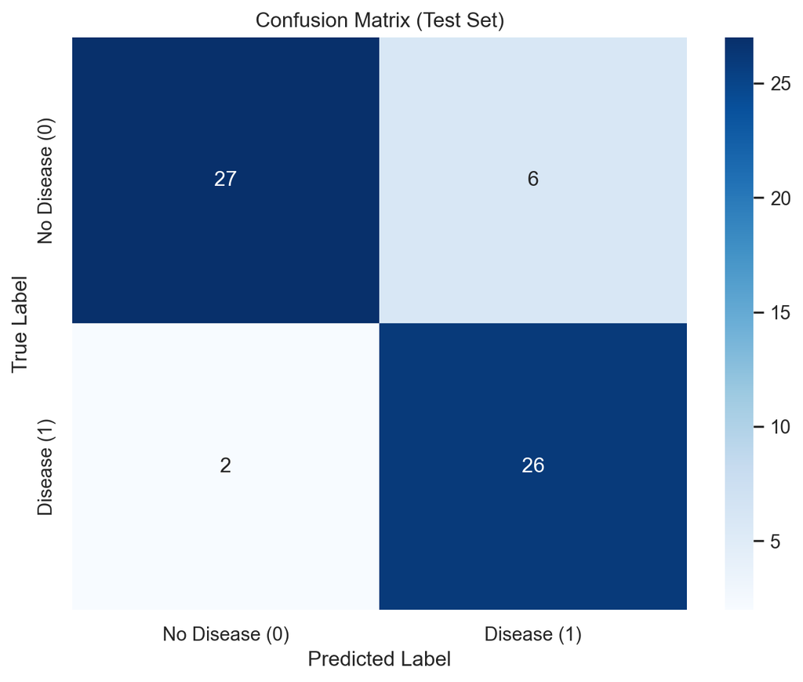

```python
cm = confusion_matrix(y_test, y_pred_test)

plt.figure(figsize=(8, 6))
sns.heatmap(cm, annot=True, fmt='d', cmap='Blues', xticklabels=['No Disease (0)', 'Disease (1)'], yticklabels=['No Disease (0)', 'Disease (1)'])
plt.title('Confusion Matrix (Test Set)')
plt.xlabel('Predicted Label')
plt.ylabel('True Label')
plt.show()
```

### Hyper Parameter Tuning

Setting up a grid of hyperparameter for the Gradient Boosting model. The grid includes different values for the number of estimators, learning rate, maximum tree depth, and subsample ratio. GridSearchCV will test all combinations of these parameters using 5-fold cross-validation to find the best configuration for maximizing the F1-score.

```python
param_grid = {
    'n_estimators': [50, 100, 150, 200],
    'learning_rate': [0.01, 0.05, 0.1, 0.2],
    'max_depth': [3, 4, 5],
    'subsample': [0.8, 0.9, 1.0]
}

gb_base = GradientBoostingClassifier(random_state=42)

grid_search = GridSearchCV(estimator=gb_base, param_grid=param_grid,
                           cv=5, n_jobs=-1, verbose=1, scoring='f1')
```

Running the grid search to train and evaluate the model for each combination of hyperparameters. Once complete, the best parameters and their corresponding cross-validation F1-score are displayed.

```python
grid_search.fit(X_train_scaled, y_train)

print(f"Best Parameters found: {grid_search.best_params_}")
print(f"Best cross-validation F1-score: {grid_search.best_score_:.4f}")
```

```
Fitting 5 folds for each of 144 candidates, totalling 720 fits
Best Parameters found: {'learning_rate': 0.1, 'max_depth': 3, 'n_estimators': 100, 'subsample': 0.9}
Best cross-validation F1-score: 0.7993
```

Using the best model from the grid search to make predictions on the training and testing datasets. The tuned model’s performance is evaluated using metrics like accuracy, recall, and precision, and a classification report is generated for the test set.

```python
best_gb_model = grid_search.best_estimator_

y_pred_test_tuned = best_gb_model.predict(X_test_scaled)
y_pred_train_tuned = best_gb_model.predict(X_train_scaled)

train_accuracy_tuned = accuracy_score(y_train, y_pred_train_tuned)
test_accuracy_tuned = accuracy_score(y_test, y_pred_test_tuned)
recall_tuned = recall_score(y_test, y_pred_test_tuned)
precision_tuned = precision_score(y_test, y_pred_test_tuned)

print(f"Tuned Training Accuracy: {train_accuracy_tuned:.4f}")
print(f"Tuned Test Accuracy: {test_accuracy_tuned:.4f}")
print(f"Tuned Recall: {recall_tuned:.4f}")
print(f"Tuned Precision: {precision_tuned:.4f}")

print("\nClassification Report (Tuned Test Set):")
print(classification_report(y_test, y_pred_test_tuned, target_names=['No Disease (0)', 'Disease (1)']))
```

```
Tuned Training Accuracy: 0.9959
Tuned Test Accuracy: 0.8525
Tuned Recall: 0.9286
Tuned Precision: 0.7879

Classification Report (Tuned Test Set):
                precision    recall  f1-score   support

No Disease (0)       0.93      0.79      0.85        33
   Disease (1)       0.79      0.93      0.85        28

      accuracy                           0.85        61
     macro avg       0.86      0.86      0.85        61
  weighted avg       0.86      0.85      0.85        61
```

```
[[26  7]
 [ 2 26]]
```

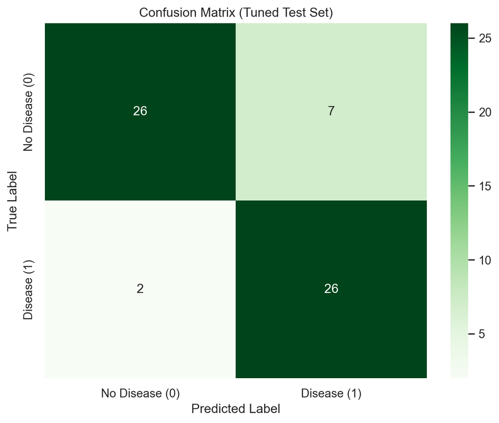

```python
cm_tuned = confusion_matrix(y_test, y_pred_test_tuned)
print(cm_tuned)

plt.figure(figsize=(8, 6))
sns.heatmap(cm_tuned, annot=True, fmt='d', cmap='Greens', xticklabels=['No Disease (0)', 'Disease (1)'], yticklabels=['No Disease (0)', 'Disease (1)'])
plt.title('Confusion Matrix (Tuned Test Set)')
plt.xlabel('Predicted Label')
plt.ylabel('True Label')
plt.show()
```

**Interpretation**: The confusion matrix for the tuned model on the test set [[26 7] [ 2 26]] shows:

- **26 True Negatives (TN)**: Correctly identified patients without heart disease.
- **7 False Positives (FP)**: Incorrectly classified patients without heart disease as having it.
- **2 False Negatives (FN)**: Incorrectly classified patients with heart disease as not having it.
- **26 True Positives (TP)**: Correctly identified patients with heart disease.

This confirms the model’s strong recall for detecting actual disease cases (only 2 missed), which aligns with the classification report and is often prioritized in medical contexts.

### Feature Importance Analysis

Analyzing the importance of each feature in the tuned model. A bar chart is generated to visualize which features contribute the most to the model’s predictions. The top 3 features are highlighted with their relative importance percentages.

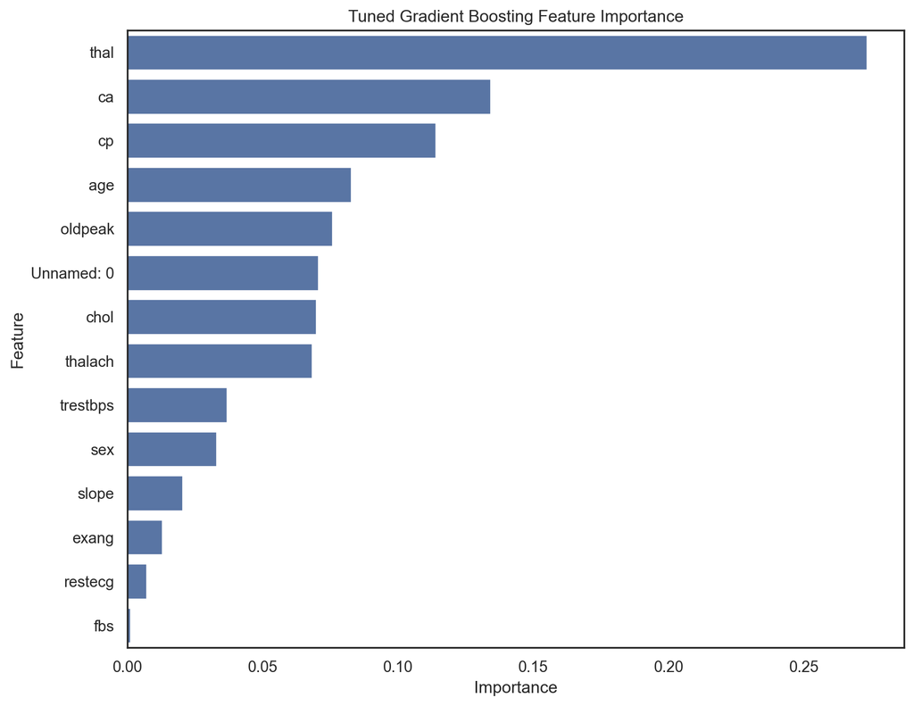

```
Top 3 Features (Tuned Model):
    Feature  Relative Importance
13    thal                   27
12      ca                   13
3       cp                   11
```

```python
feature_importances_tuned = best_gb_model.feature_importances_
importance_df_tuned = pd.DataFrame({'Feature': X.columns, 'Importance': feature_importances_tuned})
importance_df_tuned = importance_df_tuned.sort_values(by='Importance', ascending=False)

plt.figure(figsize=(10, 8))
sns.barplot(x='Importance', y='Feature', data=importance_df_tuned)
plt.title('Tuned Gradient Boosting Feature Importance')
plt.show()

importance_df_tuned['Relative Importance'] = importance_df_tuned['Importance'] / importance_df_tuned['Importance'].sum()
top_3_features_tuned = importance_df_tuned.head(3)
top_3_features_tuned['Relative Importance'] = (top_3_features_tuned['Relative Importance'] * 100).round(0).astype(int)
print("\nTop 3 Features (Tuned Model):\n", top_3_features_tuned[['Feature', 'Relative Importance']])
```

```python
feature_importances = gb_model.feature_importances_
importance_df = pd.DataFrame({'Feature': X.columns, 'Importance': feature_importances})
importance_df = importance_df.sort_values(by='Importance', ascending=False)

importance_df['Relative Importance'] = importance_df['Importance'] / importance_df['Importance'].sum()

top_3_features = importance_df.head(3)

top_3_features['Relative Importance'] = (top_3_features['Relative Importance'] * 100).round(0).astype(int)

top_3_features[['Feature', 'Relative Importance']]
```

|  | Feature | Relative Importance |
| --- | --- | --- |
| 13 | thal | 29 |
| 12 | ca | 13 |
| 3 | cp | 13 |

```python
print("\nTop 5 Features:")
importance_df.head()
```

```
Top 5 Features:
```

|  | Feature | Importance | Relative Importance |
| --- | --- | --- | --- |
| 13 | thal | 0.287791 | 0.287791 |
| 12 | ca | 0.133799 | 0.133799 |
| 3 | cp | 0.133484 | 0.133484 |
| 1 | age | 0.075847 | 0.075847 |
| 10 | oldpeak | 0.074527 | 0.074527 |

## Conclusion

This project successfully developed and evaluated a machine learning model to predict the presence of heart disease using the widely recognized UC Irvine Machine Learning Repository dataset. The primary objective was to build a reliable predictive tool that could potentially aid healthcare professionals in risk stratification.

### Significance and Implications:

The final tuned Gradient Boosting model demonstrated good predictive capability, particularly in identifying patients with heart disease (high recall). With a test accuracy of ~85% and an F1-score of 0.85 for both classes, the model shows promise as a potential decision support tool. The identification of thal, ca, and cp as key predictors aligns with clinical knowledge, reinforcing the model’s validity.

### Limitations and Future Work:

- **Dataset Size:** The analysis was based on a relatively small dataset (303 entries before outlier removal), which might limit the generalizability of the findings. Imputation Method: Mean imputation for thal is a basic approach; more sophisticated methods could be explored.
- **Tuning Impact:** Hyperparameter tuning did not significantly improve test set accuracy over the initial well-performing model in this instance, although it optimized for cross-validated F1-score. Generalizability: The model should be validated on independent, potentially larger, and more diverse datasets before any clinical application.

Future work could involve exploring other machine learning algorithms (e.g., Random Forests, SVMs, Neural Networks), investigating more advanced feature engineering techniques, employing different strategies for handling missing data and outliers, and performing external validation. Further analysis into the specific misclassifications made by the model could also provide valuable insights for improvement.

In conclusion, this analysis successfully built a Gradient Boosting model capable of predicting heart disease with reasonable accuracy and high recall, identifying key clinical indicators from the data. While further validation and refinement are necessary, the results represent a solid foundation for developing a machine learning-based tool for heart disease risk assessment.

**Author:** [Ethan Glenn](https://eglenn.dev)